# placeholder

## Anomaly Detection — Spotting the Unusual

An **anomaly** is a data point so far from normal that it deserves attention. We use the simple **3-sigma rule** — flag anything more than 3 standard deviations from the mean.

**The Rule**  
Flag a point if: |value − mean| > 3 × std dev  
In normal data only 0.3% of days would be flagged. So when the rule fires — something genuinely unusual happened.

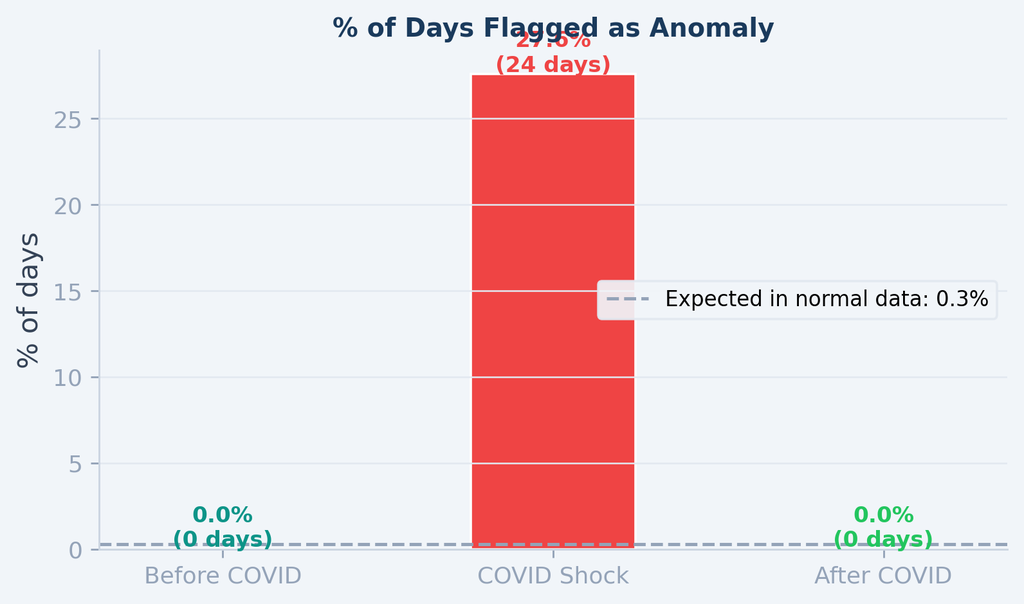

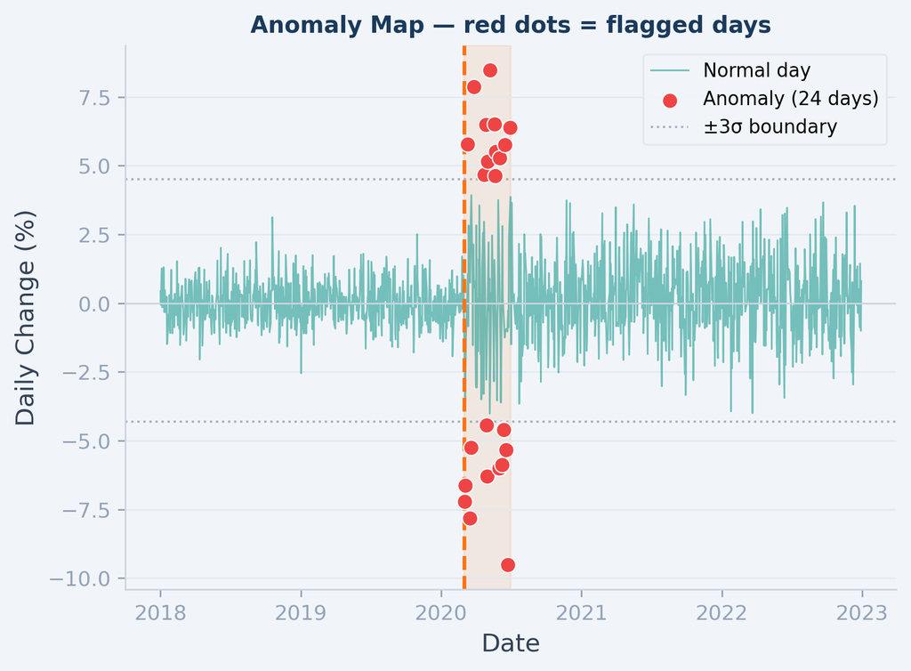

## Summary — 5 Things to Remember

01 Time Series = Data in Order

A time series is measurements over time — and **order matters.** Monday connects to Tuesday. Shuffle the rows and you destroy the information.

02 Trend = Long-Run Direction

Smooth out the noise with a **rolling mean** to reveal whether the series is going up, down, or sideways. COVID shows a clear crash then recovery.

03 Volatility = How Wild It Is

Standard deviation of daily changes measures **how much the series jumps around.** COVID pushed volatility 4× above normal — visible instantly in a rolling volatility chart.

04 Structural Break = Permanent Change

When the series changes behaviour and **stays changed,** that is a structural break. COVID doubled market volatility permanently. Models built on old data fail.

05 Anomaly Detection = Spot the Unusual

The **3-sigma rule** flags anything more than 3 standard deviations from the mean. No labels needed — the data finds its own extreme events automatically.

THE BIG IDEA

These tools work on **any data over time** — temperature, sales, hospital admissions, energy use. COVID and the stock market are just our learning example.